# SHAP_toy_example

## TalkingData AdTracking Fraud Detection Challenge

https://www.kaggle.com/c/talkingdata-adtracking-fraud-detection

### This notebook is meant to demo a new feature intepretation package -- SHAP

SHAP repo: [SHAP Github Link](https://github.com/slundberg/shap)

[figure not shown]

SHAP (SHapley Additive exPlanations) is a unified approach to explain the output of any machine learning model. SHAP connects game theory with local explanations, uniting several previous methods [1-7] and representing the only possible consistent and locally accurate additive feature attribution method based on expectations (see the [SHAP NIPS paper](http://papers.nips.cc/paper/7062-a-unified-approach-to-interpreting-model-predictions) for details).

```python
import pandas as pd
import lightgbm
import shap

# load data
model = lightgbm.Booster(model_file='model_lgbm.txt')
X = pd.read_hdf('../data/test_v3.hdf').drop('click_id', axis=1).tail(1000)   # for toy sample
```

```python
X.head()
```

|  | app | device | os | channel | hour | in_test_hh | ip_day_hour_clicks | ip_app_day_hour_clicks | ip_os_day_hour_clicks | ip_device_day_hour_clicks | ... | ip_app_channel_var_day | ip_app_channel_mean_hour | ip_day_cumcount | ip_cumcount | ip_app_day_cumcount | ip_app_cumcount | ip_device_os_day_cumcount | ip_device_os_cumcount | next_click | previous_click |
| --- | --- | --- | --- | --- | --- | --- | --- | --- | --- | --- | --- | --- | --- | --- | --- | --- | --- | --- | --- | --- | --- |
| 18789469 | 18 | 1 | 22 | 439 | 14 | 1 | 1247 | 160 | 65 | 1046 | ... | 1.198155 | 10.756757 | 5343 | 5343 | 687 | 687 | 152 | 152 | NaN | 3.0 |
| 18789470 | 9 | 1 | 19 | 127 | 14 | 1 | 50 | 33 | 33 | 50 | ... | 0.058654 | 12.107693 | 210 | 210 | 68 | 68 | 103 | 103 | NaN | 4.0 |
| 18789471 | 3 | 1 | 13 | 115 | 14 | 1 | 262 | 18 | 151 | 170 | ... | 1.574375 | 10.609756 | 746 | 746 | 37 | 37 | 231 | 231 | NaN | 4.0 |
| 18789472 | 2 | 1 | 13 | 243 | 14 | 1 | 83 | 10 | 35 | 79 | ... | 1.500000 | 9.166667 | 392 | 392 | 39 | 39 | 63 | 63 | NaN | 1934.0 |
| 18789473 | 27 | 1 | 11 | 153 | 14 | 1 | 234 | 4 | 19 | 230 | ... | 1.353725 | 9.156863 | 895 | 895 | 7 | 7 | 34 | 34 | NaN | NaN |

5 rows × 42 columns

## SHAP explanation

### Aggregate level overview

To get an overview of which features are most important for a model we can plot the SHAP values of every feature for every sample. The plot below sorts features by the sum of SHAP value magnitudes over all samples, and uses SHAP values to show the distribution of the impacts each feature has on the model output. The color represents the feature value (red high, blue low).

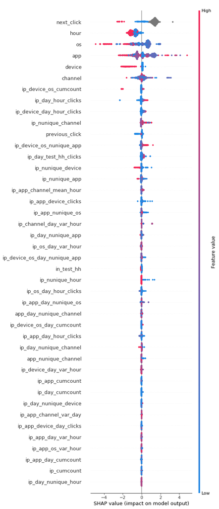

```python
# load javascript code
shap.initjs()
# explain all the predictions in the test set
shap_values = shap.TreeExplainer(model).shap_values(X)
shap.summary_plot(shap_values, X, max_display=50)
```

Wow, this is interesting!

1. It reveals that high value in *next_click* would lower the prediction probability of being fraudulent clicks
2. Besides the original feature, *next_click* is the only feature that provides a huge impact to the model
3. There are some high leveraged samples; Eg. there are a cluster of samples far away from the middle, those and outliers and they have high probability being fraudulent

### Individual sample feature contribution breakdown

The below explanation shows features each contributing to push the model output from the base value (the average model output over the training dataset we passed) to the model output. Features pushing the prediction higher are shown in red, those pushing the prediction lower are in blue.

```python
shap.force_plot(shap_values[0, :], X.iloc[0,:])
```

**Visualization omitted, Javascript library not loaded!**  
Have you run `initjs()` in this notebook? If this notebook was from another user you must also trust this notebook (File -> Trust notebook). If you are viewing this notebook on github the Javascript has been stripped for security.

### Stack all samples together

If we take many explanations such as the one shown above, rotate them 90 degrees, and then stack them horizontally, we can see explanations for an entire dataset (in the notebook this plot is interactive):

```python
shap.force_plot(shap_values, X)
```

**Visualization omitted, Javascript library not loaded!**  
Have you run `initjs()` in this notebook? If this notebook was from another user you must also trust this notebook (File -> Trust notebook). If you are viewing this notebook on github the Javascript has been stripped for security.

### SHAP Dependence Plots

SHAP dependence plots show the effect of a single feature across the whole dataset. They plot a feature's value vs. the SHAP value of that feature across many samples. SHAP dependence plots are similar to partial dependence plots, but account for the interaction effects present in the features, and are only defined in regions of the input space supported by data. The vertical dispersion of SHAP values at a single feature value is driven by interaction effects, and another feature is chosen for coloring to highlight possible interactions.

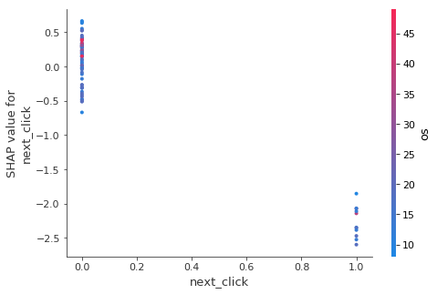

```python
shap.dependence_plot("next_click", shap_values, X)
```

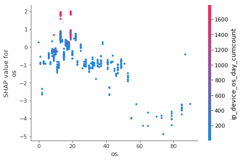

```python
shap.dependence_plot("os", shap_values, X)
```

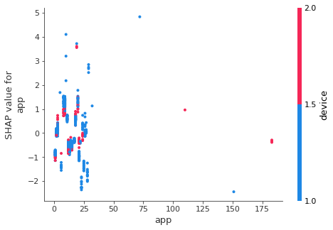

```python
shap.dependence_plot("app", shap_values, X)
```

### Compute SHAP Interaction Values

See the Tree SHAP paper for more details, but briefly, SHAP interaction values are a generalization of SHAP values to higher order interactions. Fast exact computation of pairwise interactions are implemented in the latest version of XGBoost with the pred_interactions flag. With this flag XGBoost returns a matrix for every prediction, where the main effects are on the diagonal and the interaction effects are off-diagonal. The main effects are similar to the SHAP values you would get for a linear model, and the interaction effects captures all the higher-order interactions are divide them up among the pairwise interaction terms. Note that the sum of the entire interaction matrix is the model's output, and so the interaction effects on the off-diagonal are split in half (since there are two of each). When plotting interaction effects the SHAP package automatically multiplies the off-diagonal values by two to get the full interaction effect.

```python
# shap_interaction_values = shap.TreeExplainer(model).shap_interaction_values(X)
```

#### DO NOT SUPPORT lighgbm YET

### SHAP Interaction Value Summary Plot

A summary plot of a SHAP interaction value matrix plots a matrix of summary plots with the main effects on the diagonal and the interaction effects off the diagonal.

```python
# shap.summary_plot(shap_interaction_values, X)
```

### SHAP Interaction Value Dependence Plots

Running a dependence plot on the SHAP interaction values a allows us to separately observe the main effects and the interaction effects.

```python
# shap.dependence_plot(
#     ("next_click", "next_click"),
#     shap_interaction_values,
#     X
# )
```